# Exercícios - Estatística I

### Questão 1

Os exercícios de 1 a 5 serão desenvolvidos utilizando o *dataset* `Titanic.csv`:

Calcule a frequência absoluta para os sobreviventes no *Titanic*.

**Dica.:** Utilize a função `.value_counts()`

Carregando as principais bibliotecas que iremos utilizar:

```python
import pandas as pd
import numpy as np
import matplotlib.pyplot as plt
import seaborn as sns

# sns.load_dataset('titanic')
```

```python
# Print carregando o dataset Titanic
# titanic = pd.read_csv("titanic.csv")
titanic = sns.load_dataset('titanic')

# Print das primeiras linhas
titanic.head()
```

|  | survived | pclass | sex | age | sibsp | parch | fare | embarked | class | who | adult_male | deck | embark_town | alive | alone |
| --- | --- | --- | --- | --- | --- | --- | --- | --- | --- | --- | --- | --- | --- | --- | --- |
| 0 | 0 | 3 | male | 22.0 | 1 | 0 | 7.2500 | S | Third | man | True | NaN | Southampton | no | False |
| 1 | 1 | 1 | female | 38.0 | 1 | 0 | 71.2833 | C | First | woman | False | C | Cherbourg | yes | False |
| 2 | 1 | 3 | female | 26.0 | 0 | 0 | 7.9250 | S | Third | woman | False | NaN | Southampton | yes | True |
| 3 | 1 | 1 | female | 35.0 | 1 | 0 | 53.1000 | S | First | woman | False | C | Southampton | yes | False |
| 4 | 0 | 3 | male | 35.0 | 0 | 0 | 8.0500 | S | Third | man | True | NaN | Southampton | no | True |

```python
# Print do Título
print("Tabela de frequência ABSOLUTA da coluna 'Survived':")

# Print da Tabela de Frequencia absoluta
display(titanic["survived"].value_counts())
```

```
Tabela de frequência ABSOLUTA da coluna 'Survived':
```

```
0    549
1    342
Name: survived, dtype: int64
```

### Questão 2

Os exercícios de 1 a 5 serão desenvolvidos utilizando o *dataset* `Titanic.csv`:

Calcule a frequência relativa, relativa percentual e acumulativa para os sobreviventes no *Titanic*.

**Dica.:** Utilize a função `.value_counts()`

```python
# Print do Titulo
print("Tabela de frequência RELATIVA da coluna 'Survived':")

# Print da Tabela de Frequencia relativa
display(titanic["survived"].value_counts(normalize=True))
```

```
Tabela de frequência RELATIVA da coluna 'Survived':
```

```
0    0.616162
1    0.383838
Name: survived, dtype: float64
```

```python
# Print do Titulo
print("Tabela de frequência PERCENTUAL da coluna 'Survived':")

# Print da Tabela de Frequencia Percentual
titanic["survived"].value_counts(normalize=True).apply(lambda x: str(round(x*100, 2)) + "%")
```

```
Tabela de frequência PERCENTUAL da coluna 'Survived':
```

```
0    61.62%
1    38.38%
Name: survived, dtype: object
```

```python
# Print do Titulo
print("Tabela de frequência Acumulada da coluna 'Survived':")

# Print da Tabela de Frequencia Percentual
titanic["survived"].value_counts(normalize=True).cumsum()
```

```
Tabela de frequência Acumulada da coluna 'Survived':
```

```
0    0.616162
1    1.000000
Name: survived, dtype: float64
```

### Questão 3

Os exercícios de 1 a 5 serão desenvolvidos utilizando o *dataset* `Titanic.csv`:

Utilizando a coluna `Age` do *dataset Titanic*, defina as principais métricas estatísticas para essa variável tais como:

- Média;
- Desvio Padrão;
- Mínimo;
- Primeiro Quartil;
- Segundo Quartil (Mediana);
- Terceiro Quartil;
- Distância Interquartil (IQR);
- Máximo;
- Skewness;
- Moda.

```python
# Calculo das Metricas para Idade
print("Média de idades:", titanic["age"].mean())
print("Desvio padrão de idades:", titanic["age"].std())
print("\nIdade mínima:", titanic["age"].min())
print("\nIdade Q1:", titanic["age"].quantile(0.25))
print("Mediana de idades:", titanic["age"].median())
print("Idade Q3:", titanic["age"].quantile(0.75))
print("IQR das idades:", titanic["age"].quantile(0.75) - titanic["age"].quantile(0.25))
print("\nIdade máxima:", titanic["age"].max())
print("\nSkewness das idades:", titanic["age"].skew())
print("\nIdade(s) mais comum(s):")
display(titanic["age"].mode())
```

```
Média de idades: 29.69911764705882
Desvio padrão de idades: 14.526497332334044

Idade mínima: 0.42

Idade Q1: 20.125
Mediana de idades: 28.0
Idade Q3: 38.0
IQR das idades: 17.875

Idade máxima: 80.0

Skewness das idades: 0.38910778230082704

Idade(s) mais comum(s):
```

```
0    24.0
dtype: float64
```

```python
titanic['age'].describe()
```

```
count    714.000000
mean      29.699118
std       14.526497
min        0.420000
25%       20.125000
50%       28.000000
75%       38.000000
max       80.000000
Name: age, dtype: float64
```

### Questão 4

Os exercícios de 1 a 5 serão desenvolvidos utilizando o *dataset* `Titanic.csv`:

Crie um gráfico de distribuição das idades dos passageiros do *Titanic* e identifique os pontos onde se encontram a média, mediana e moda das idades.

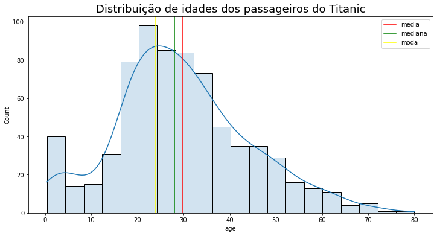

```python
# Define o tamanho da figura
plt.figure(figsize=(12, 6))

# Define o Titulo
plt.title("Distribuição de idades dos passageiros do Titanic", size=18)

# Plot do Histograma
sns.histplot(titanic["age"], kde=True, alpha=0.2)

# plotando média
plt.axvline(x=titanic["age"].mean(), color="red", label="média")

# plotando a mediana
plt.axvline(titanic["age"].median(), color="green", label="mediana")

# Loop para plotar as modas
for i in range(titanic["age"].mode().shape[0]):
    plt.axvline(titanic["age"].mode()[i], color="yellow", label="moda")

# Cria uma legenda
plt.legend()

# Mostra o Gráfico
plt.show()
```

### Questão 5

Os exercícios de 1 a 5 serão desenvolvidos utilizando o *dataset* `Titanic.csv`:

Ainda trabalhando com os valores das idades crie três *Boxplots*:

- *Boxplot* das idades para todos os passageiros;
- *Boxplot* das idades dos passageiros separados pelo sexo.
- *Boxplot* das idades dos passageiros separados pelo sexo e por sobreviventes.

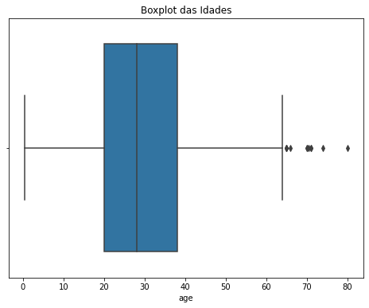

```python
# Define o tamanho da figura
plt.figure(figsize=(8, 6))

# Cria um BoxPlot
sns.boxplot(data=titanic, x="age")

# Cria um titulo
plt.title("Boxplot das Idades")

#Mostra o gráfico
plt.show()
```

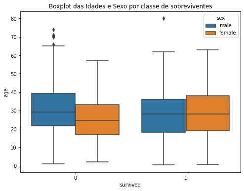

```python
# Define o tamanho da figura
plt.figure(figsize=(8, 6))

# Plot do Boxplot
sns.boxplot(data=titanic, y="age", x="survived", hue="sex")

# Cria um titulo
plt.title("Boxplot das Idades e Sexo por classe de sobreviventes")

# Mostra o gráfico
plt.show()
```

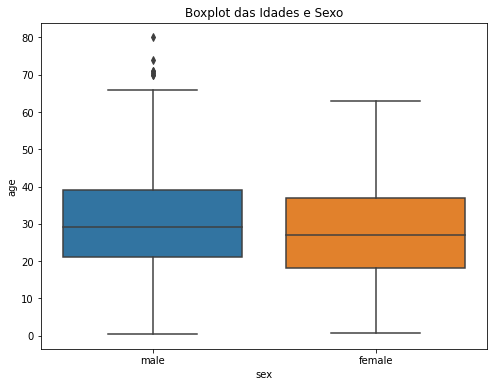

```python
# Define o tamanho da figura
plt.figure(figsize=(8, 6))

# Plot do Boxplot
sns.boxplot(data=titanic, y="age", x="sex")

# Cria um titulo
plt.title("Boxplot das Idades e Sexo")

# Mostra o gráfico
plt.show()
```

Com o dataset `penguins`, responda as questões abaixo:

sns.load_dataset('penguins')

### Questão 6

Classifique o tipo de dado de cada coluna

```python
penguins = sns.load_dataset('penguins')
penguins
```

|  | species | island | bill_length_mm | bill_depth_mm | flipper_length_mm | body_mass_g | sex |
| --- | --- | --- | --- | --- | --- | --- | --- |
| 0 | Adelie | Torgersen | 39.1 | 18.7 | 181.0 | 3750.0 | Male |
| 1 | Adelie | Torgersen | 39.5 | 17.4 | 186.0 | 3800.0 | Female |
| 2 | Adelie | Torgersen | 40.3 | 18.0 | 195.0 | 3250.0 | Female |
| 3 | Adelie | Torgersen | NaN | NaN | NaN | NaN | NaN |
| 4 | Adelie | Torgersen | 36.7 | 19.3 | 193.0 | 3450.0 | Female |
| ... | ... | ... | ... | ... | ... | ... | ... |
| 339 | Gentoo | Biscoe | NaN | NaN | NaN | NaN | NaN |
| 340 | Gentoo | Biscoe | 46.8 | 14.3 | 215.0 | 4850.0 | Female |
| 341 | Gentoo | Biscoe | 50.4 | 15.7 | 222.0 | 5750.0 | Male |
| 342 | Gentoo | Biscoe | 45.2 | 14.8 | 212.0 | 5200.0 | Female |
| 343 | Gentoo | Biscoe | 49.9 | 16.1 | 213.0 | 5400.0 | Male |

344 rows × 7 columns

```python
penguins.info()
```

```
<class 'pandas.core.frame.DataFrame'>
RangeIndex: 344 entries, 0 to 343
Data columns (total 7 columns):
 #   Column             Non-Null Count  Dtype
---  ------             --------------  -----
 0   species            344 non-null    object
 1   island             344 non-null    object
 2   bill_length_mm     342 non-null    float64
 3   bill_depth_mm      342 non-null    float64
 4   flipper_length_mm  342 non-null    float64
 5   body_mass_g        342 non-null    float64
 6   sex                333 non-null    object
dtypes: float64(4), object(3)
memory usage: 18.9+ KB
```

Quantitativo contínuos: bill_length_mm, bill_depth_mm, flipper_length_mm, body_mass_g,

Qualitativos nominais: species, island, sex

### Questão 7

Calcule a frequência absoluta para cada espécie de pinguim

```python
print("Tabela de frequência ABSOLUTA da coluna 'species':")

# Print da Tabela de Frequencia absoluta
display(penguins["species"].value_counts())
```

```
Tabela de frequência ABSOLUTA da coluna 'species':
```

```
Adelie       152
Gentoo       124
Chinstrap     68
Name: species, dtype: int64
```

### Questão 8

Calcule a frequência relativa, relativa percentual e acumulativa de cada espécie de pinguim

```python
print("Tabela de frequência RELATIVA da coluna 'species':")
display(penguins["species"].value_counts(normalize=True))
```

```
Tabela de frequência RELATIVA da coluna 'species':
```

```
Adelie       0.441860
Gentoo       0.360465
Chinstrap    0.197674
Name: species, dtype: float64
```

```python
print("Tabela de frequência PERCENTUAL da coluna 'species':")

# Print da Tabela de Frequencia Percentual
penguins["species"].value_counts(normalize=True).apply(lambda x: str(round(x*100, 2)) + "%")
```

```
Tabela de frequência PERCENTUAL da coluna 'species':
```

```
Adelie       44.19%
Gentoo       36.05%
Chinstrap    19.77%
Name: species, dtype: object
```

```python
print("Tabela de frequência Acumulada da coluna 'species':")

# Print da Tabela de Frequencia Percentual
penguins["species"].value_counts(normalize=True).cumsum().apply(lambda x: str(round(x*100, 2)) + "%")
```

```
Tabela de frequência Acumulada da coluna 'species':
```

```
Adelie       44.19%
Gentoo       80.23%
Chinstrap    100.0%
Name: species, dtype: object
```

### Questão 9

Utilizando a coluna `body_mass_g` do dataset Penguins, defina as principais métricas estatísticas para essa variável tais como:

- Média;
- Desvio Padrão;
- Mínimo;
- Primeiro Quartil;
- Segundo Quartil (Mediana);
- Terceiro Quartil;
- Distância Interquartil (IQR);
- Máximo;
- Skewness;
- Moda.

```python
penguins['body_mass_g'].describe()
```

```
count     342.000000
mean     4201.754386
std       801.954536
min      2700.000000
25%      3550.000000
50%      4050.000000
75%      4750.000000
max      6300.000000
Name: body_mass_g, dtype: float64
```

```python
print("IQR :", penguins["body_mass_g"].quantile(0.75) - penguins["body_mass_g"].quantile(0.25))
print("\nSkewness das massas:", penguins["body_mass_g"].skew())
print("\nIdade(s) mais comum(s):")
display(penguins["body_mass_g"].mode())
```

```
IQR : 1200.0

Skewness das massas: 0.470329330480123

Idade(s) mais comum(s):
```

```
0    3800.0
dtype: float64
```

### Questão 10

Crie um gráfico da distribuição da massa dos pinguins e identifique os pontos onde se encontram a média, mediana e moda das idades.

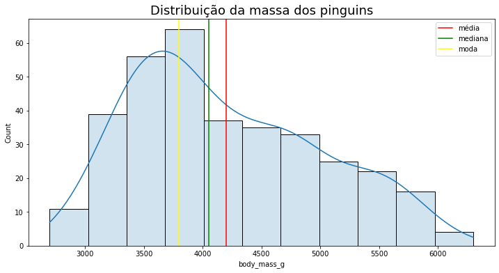

```python
# Define o tamanho da figura
plt.figure(figsize=(12, 6))

# Define o Titulo
plt.title("Distribuição da massa dos pinguins", size=18)

# Plot do Histograma
sns.histplot(penguins["body_mass_g"], kde=True, alpha=0.2)

# plotando média
plt.axvline(x=penguins["body_mass_g"].mean(), color="red", label="média")

# plotando a mediana
plt.axvline(penguins["body_mass_g"].median(), color="green", label="mediana")

# Loop para plotar as modas
for i in range(penguins["body_mass_g"].mode().shape[0]):
    plt.axvline(penguins["body_mass_g"].mode()[i], color="yellow", label="moda")

# Cria uma legenda
plt.legend()

# Mostra o Gráfico
plt.show()
```

### Questão 11

Ainda trabalhando com os valores das massas dos pinguins crie três Boxplots:

- Boxplot da massa para todos os pinguins
- Boxplot da massas dos pinguins separados pelo sexo.
- Boxplot da massas dos pinguins separados pelo sexo e pela espécies.

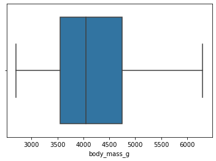

```python
sns.boxplot(data=penguins, x="body_mass_g")#, x="Survived", hue="Sex")
```

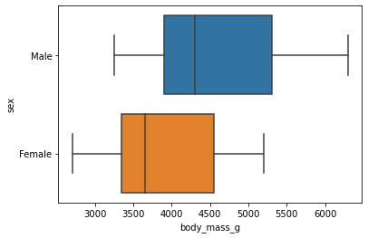

```python
sns.boxplot(data=penguins, x="body_mass_g", y="sex")
```

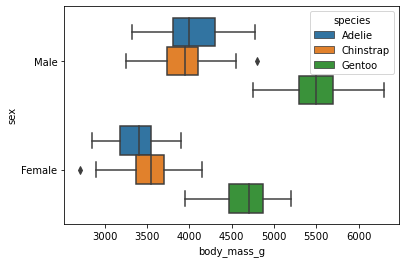

```python
sns.boxplot(data=penguins, x="body_mass_g", y="sex", hue='species')
```